# GoMx Gervais’ beaked whale habitat models: Density with neural nets

Kaitlin Frasier

Scripps Institution of Oceanography, UC San Diego

08 February 2021

# 1. Exploratory analysis

## 1.1 Data Inputs

NOAA SEFSC visual data goes back to 1992, but as shown in the figure below, many predictor variables are only available starting in 2003, therefore earlier visual data is currently excluded from further analyses.

Note: Future work could use monthly climatologies (averages) so that older sightings data could be used. Some dynamic drivers like eddy and front locations would not be able to be considered using that approach.

**Visual data predictor variable availability:**

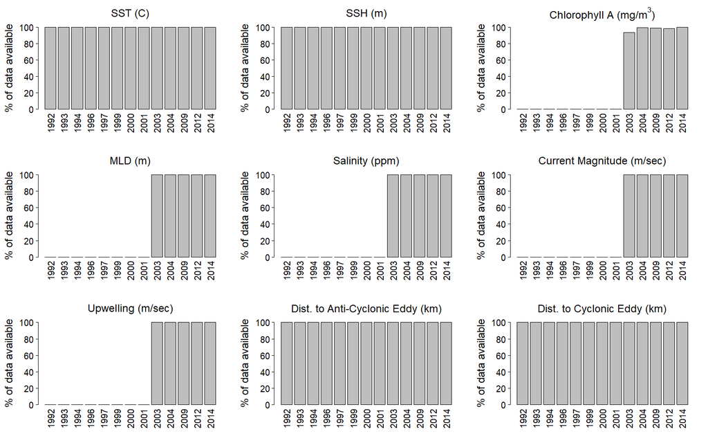

### 1.1.1 Splitting into testing and training sets

The data are split into training and testing sets. In this case, visual data from 2009 and acoustic data from 2013 were used only for testing. Only observations from 2003 or later were used for modeling due to covariate limitations.

### 1.1.2 Map of visual sightings data

The visual data selected for modeling are displayed on the map below. Data from 2009 were held back for testing. Blue markers indicate HARP locations.

[interactive chart not shown]

### 1.1.3 Time series of acoustic data

The time series below show timeseries of estimated densities from passive acoustic data used for modeling (Densities were calculated following methods detailed in [1]). Data from 2011 and 2012 were used for training, and 2013 data was held back for testing.

**Acoustic Timeseries:**

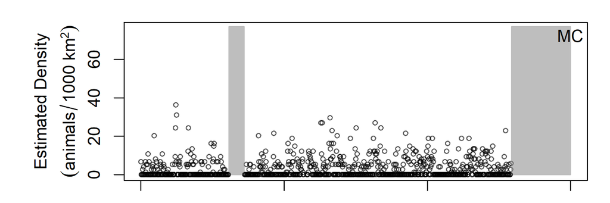

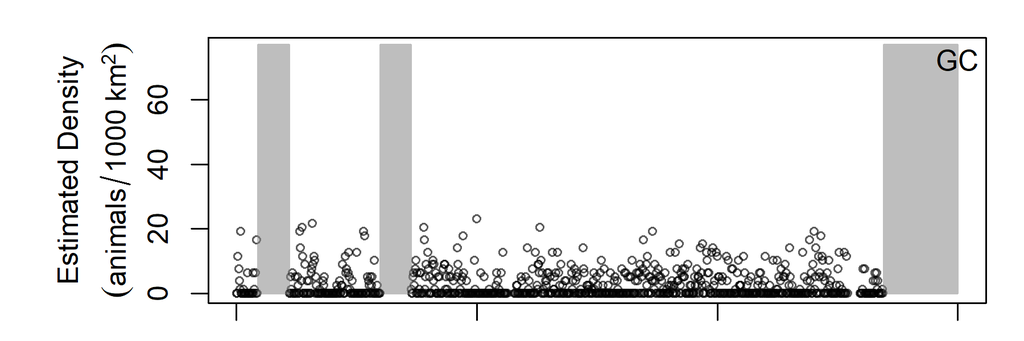

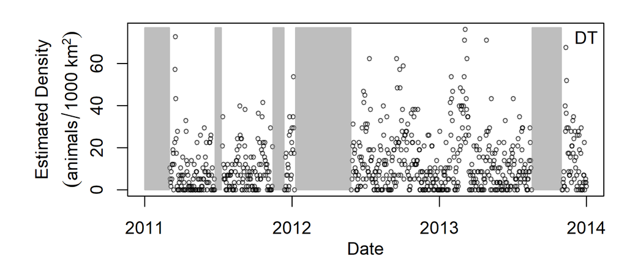

## 1.2 Examination of covariates

### 1.2.1 Covariate distribution check

**Distributions of covariates from acoustic observations (training data only):**

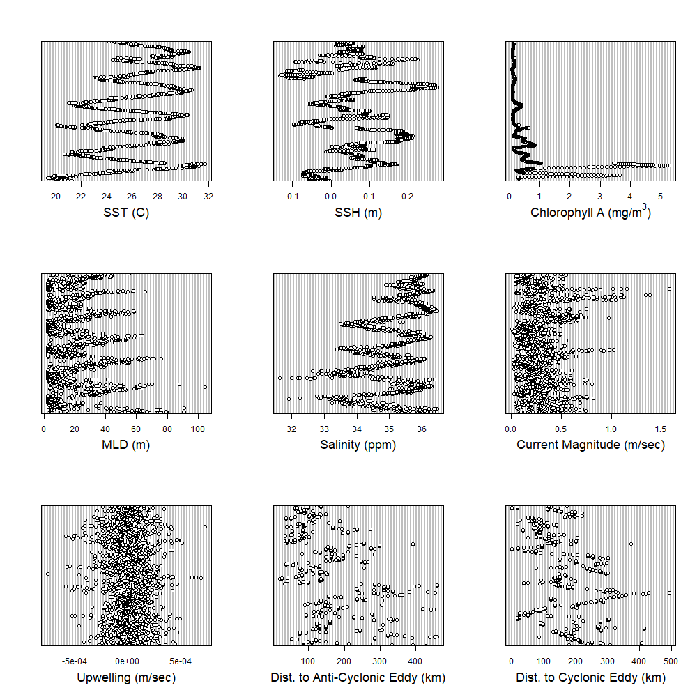

**Distributions of covariates from the visual observations (training data only):**

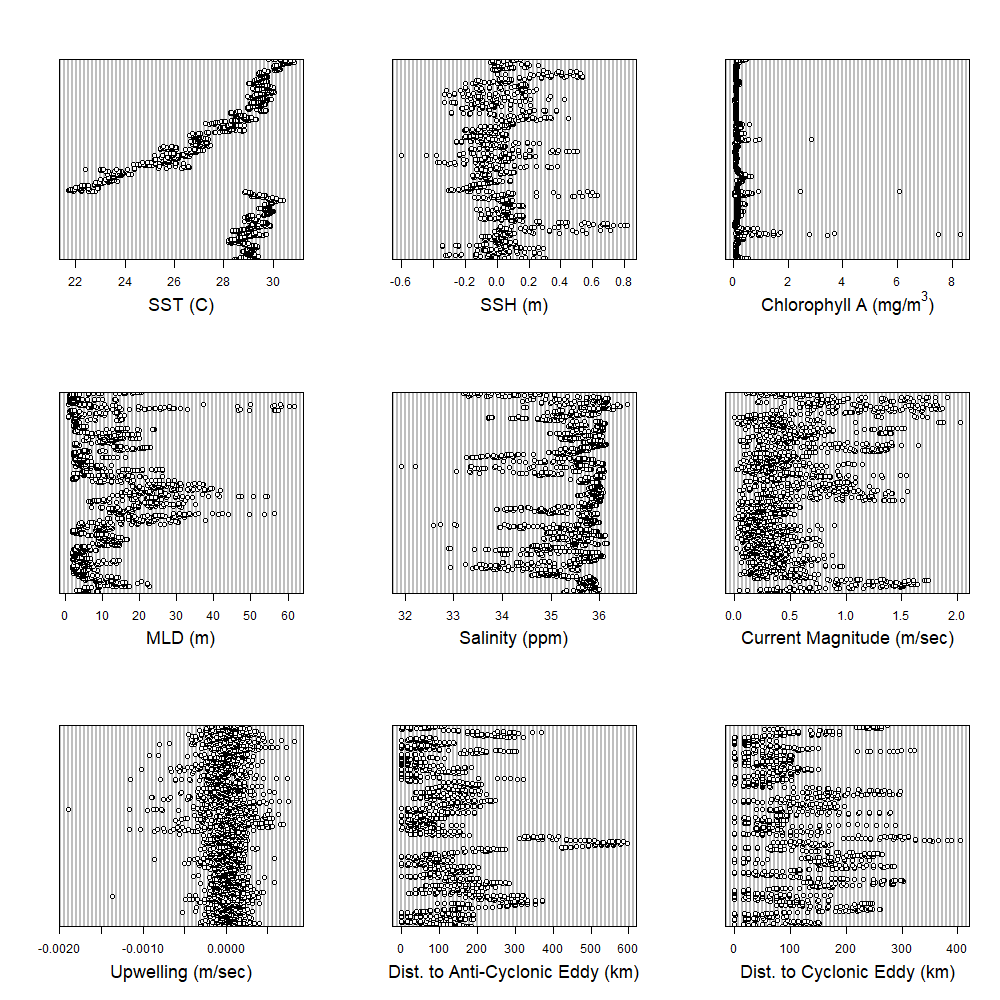

Some of these covariates are more or less interrelated. Correlations are examined in the figure below. Numbers closer to 1 above the diagonal in the figure below represent correlation coefficients. If a pair of covariates is highly-correlated only one should typically be used in the model.

**Covariate Correlations:**

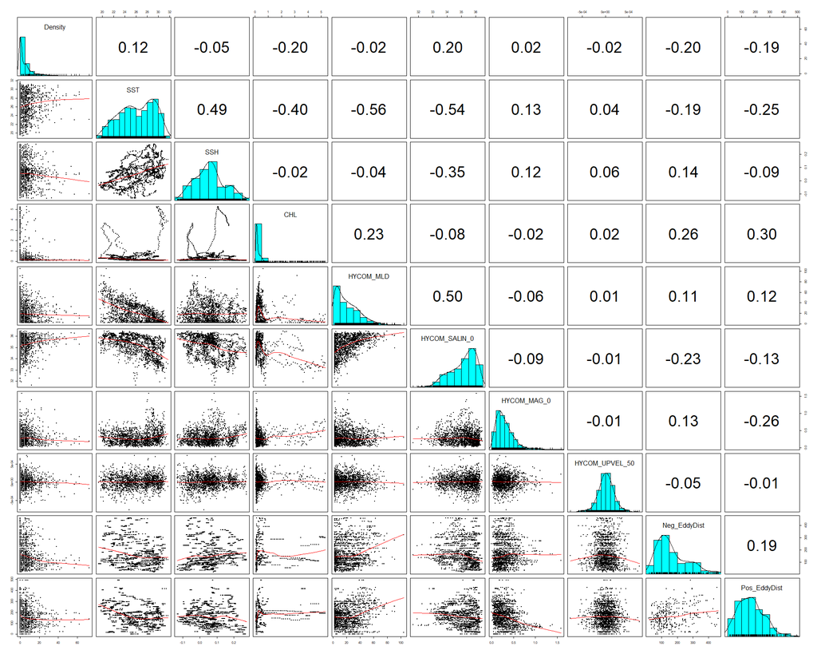

### 1.2.3 Preliminary check of predictive power

**Acoustic kernel densities:**

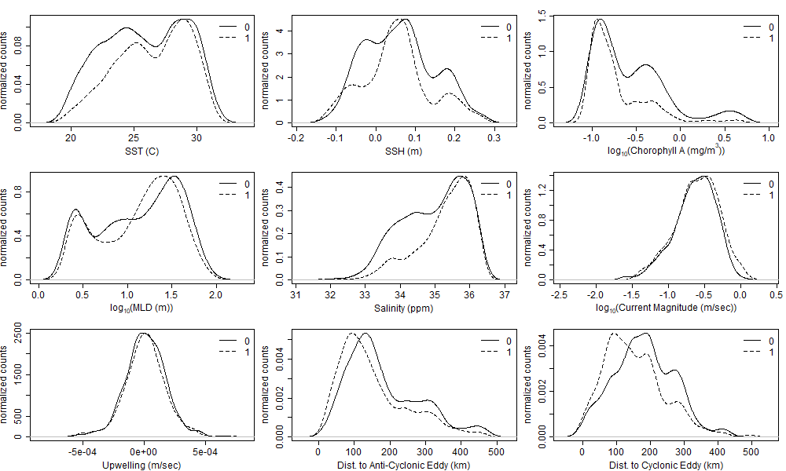

**Visual kernel densities:**

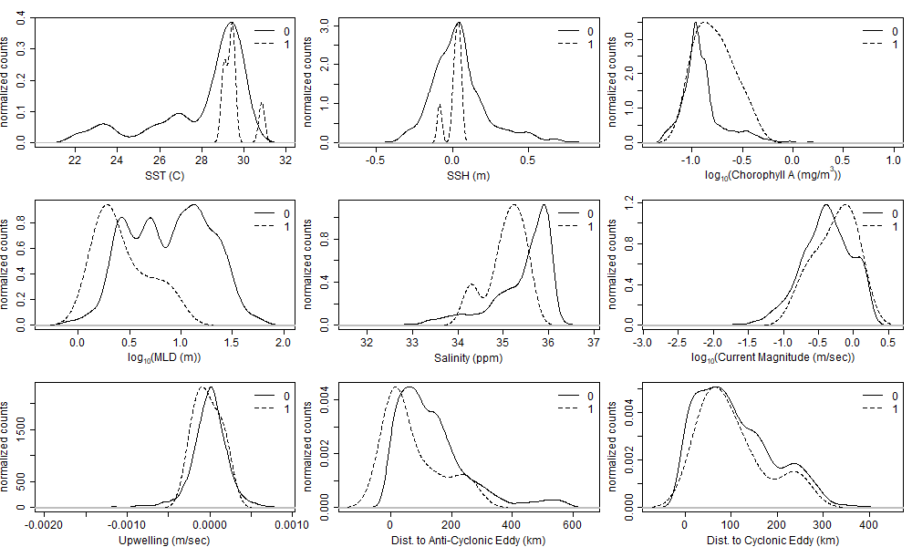

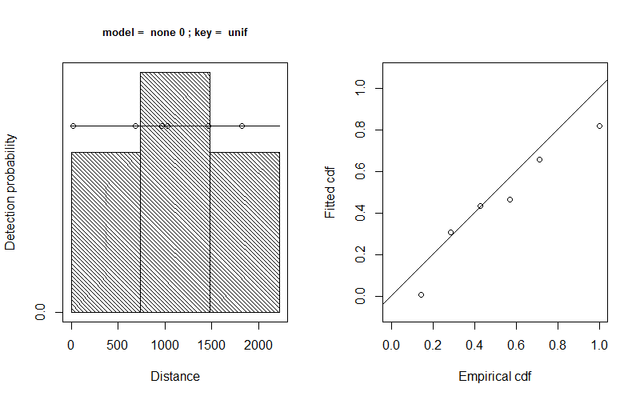

# 2. Model Fitting

Models were fit using avnnet from the caret package in R.

## 2.1 Run Models

Run NNs on Acoustic and Visual datasets.

## 2.2 Model Comparisons

```
## [1] "RMSE (lower is better)"
```

```
##                                   4     6     8    10    12    14
## Acoustic - Acoustic test data 11.34 11.35 11.30 11.31 11.35 11.17
## Acoustic - Visual test data    4.97  5.65  5.36  5.68  5.69  5.61
## Visual - Visual test data      3.43  3.43  3.43  3.43  3.43  3.43
## Visual - Acoustic test data   13.08 13.09 13.09 13.09 13.09 13.09
```

```
## [1] "Best acoustic model has 14 nodes."
```

```
## [1] "Best visual model has 6 nodes."
```

## 2.3 Variable Importance

For the best model in each category, the importance of each input variable was calculated across the 50 model iterations.

|  | AcOnly | VisOnly |
| --- | --- | --- |
| SST | 11.7 | 5.1 |
| SSH | 11.3 | 13.3 |
| log10_CHL | 13.1 | 5.2 |
| log10_HYCOM_MLD | 7.2 | 14.9 |
| HYCOM_SALIN_0 | 13.4 | 19.5 |
| log10_HYCOM_MAG_0 | 9.1 | 16.3 |
| HYCOM_UPVEL_50 | 7.6 | 9.5 |
| Neg_EddyDist | 14.6 | 11.3 |
| Pos_EddyDist | 11.9 | 5.0 |

*Best acoustic network:*

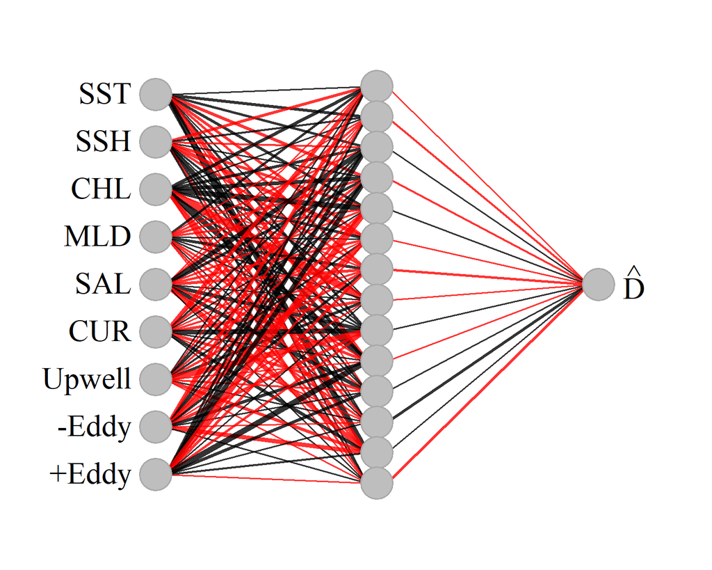

*Best visual network:*

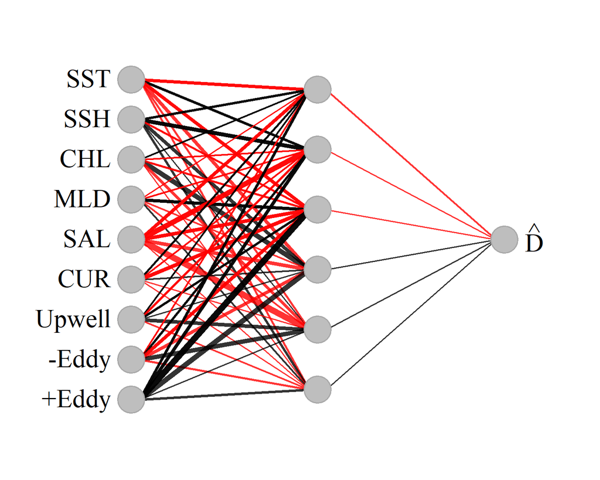

# 3. Model Predictions

## 3.1 Temporal predictions

Predictions were made on the acoustic test dataset, and compared with actual observations for 2013. The predicted density of animals at each site was compared with the estimated daily density from the pasive acoustic record.

### 3.1.1 Acoustic-only prediction

### 3.1.2 Visual-only prediction

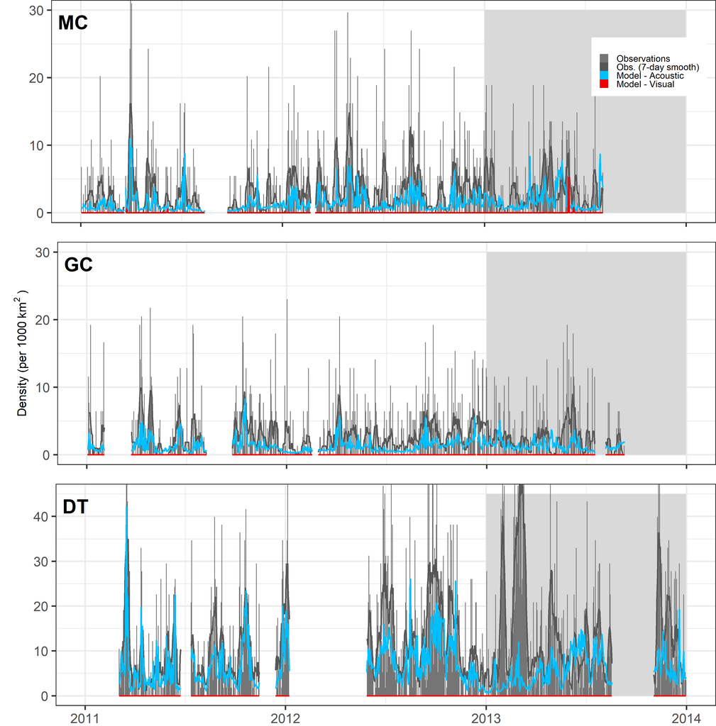

## 3.2 Spatial predictions

Models were evaluated for summer (July 2009) and winter(January 2009) across the entire Gulf of Mexico (US EEZ beyond the 200m contour).

Each grid cell in the following maps represents a 10x10 km square. Densities are therefore shown as estimated number of animals per 100 km<sup>2</sup>.

### 3.2.1 Summer 2009 predictions

**Summer 2009 predicted distribution and test sightings:**

[interactive chart not shown]

**Summer 2009 prediction uncertainty:**

[interactive chart not shown]

### 3.2.2 Winter 2009 predictions

**Winter 2009 predicted distribution:**

[interactive chart not shown]

**Winter 2009 prediction uncertainty:**

[interactive chart not shown]

### 3.3.3 How does hidden layer size change spatial predictions?

[interactive chart not shown]

# 4. Monthly model predictions

Spatial model predictions were generated using climatological means of oceanographic variables, averaged by month between 2003 and 2015.

[interactive chart not shown]

1. Frasier KE, Wiggins SM, Harris D, Marques TA, Thomas L, Hildebrand JA. Delphinid echolocation click detection probability on near-seafloor sensors. The Journal of the Acoustical Society of America. 2016;140: 1918–1930. doi:http://dx.doi.org/10.1121/1.4962279